# Are Offenses Making a Strategic Mistake by Not Utilizing a Fullback?

An Analytics-Based Evaluation of the Fullback Position in the Modern NFL

# Introduction

## The Question

- The fullback is a dying position in the NFL
- Usage has declined significantly over the past decade
- But is this decline analytically justified?
- **Research Question:** Are offenses making a strategic mistake by not utilizing a fullback?

## Why It Matters

- Offensive coordinators make personnel decisions every game
- If fullbacks provide measurable value, teams leaving them off rosters are losing wins
- Analytics can help answer this question of should offenses use fullbacks

# Data

## Data Sources

- **Play-by-Play Data** from `nflreadr` — 2020 to 2024 seasons
- **Participation Data** from `nflreadr` — player-level personnel tracking
- Position id`offense_positions` column (available 2023-2024 only)
- Fullback id using `"1 FB"` in `offense_personnel` string

## Key Variables

- `has_fullback` — whether a fullback was in the personnel grouping
- `situation_type` — goal line, short yardage, or base down
- Outcome variables: `short_yardage_success`, `goal_line_success`, `epa`
- Controls: down, yards to go, yard line, defenders in box, WPA, drive metrics

## Situation Definitions

- **Goal Line** — yardline ≤ 5
- **Short Yardage** — 3rd or 4th down with ≤ 2 yards to go
- **Base Down** — 1st and 10, or 2nd and 5-10

# Methods

## Analytical Approach

Three-stage analysis: - **Plus/Minus** — raw comparison of outcomes with and without fullback - **Base Models** — logistic and linear regression controlling for situational factors - **Random Effects Models** — mixed models accounting for individual fullback identity

## Base Models

- Short Yardage & Goal Line → logistic regression (`glm`, binomial)
- Base Down → linear regression (`lm`)
- Controls selected using Pearson correlation feature selection
- Ran on full dataset (all NFL teams, 2020-2024)

## Random Effects Models

- Mixed effects models (`glmer`/`lmer`) using `lme4`
- Random intercept and slope for `has_fullback` by `fullback_id`
- Limited to 2023-2024 (only seasons with position-level data)
- 15 identified primary fullbacks across teams and seasons

# Results

## Plus/Minus Summary

| situation_type | plays_0 | plays_1 | avg_epa_0 | avg_epa_1 | success_rate_0 | success_rate_1 | avg_yards_0 | avg_yards_1 | epa_plus_minus | success_plus_minus | yards_plus_minus |
| --- | --- | --- | --- | --- | --- | --- | --- | --- | --- | --- | --- |
| base_down | 84806 | 11299 | 0.001 | 0.011 | 0.422 | 0.416 | 5.818 | 5.910 | 0.010 | -0.007 | 0.091 |
| goal_line | 6019 | 850 | 0.043 | 0.035 | 0.500 | 0.513 | 1.113 | 1.021 | -0.008 | 0.013 | -0.092 |
| short_yardage | 7542 | 984 | 0.122 | 0.119 | 0.651 | 0.669 | 4.725 | 4.369 | -0.002 | 0.017 | -0.356 |

## Short Yardage Results

- Fullback presence is **significant** across all short yardage models
- All plays: p = 0.009, Rush: p = 0.046, Pass: p = 0.047
- Having a fullback increases probability of gaining 1+ yard

## Short Yardage - All Plays

Short Yardage - All Plays

| Predictor | Estimate | Std. Error | z value | Pr(>\|z\|) |
| --- | --- | --- | --- | --- |
| (Intercept) | -11.252 | 1.163 | -9.676 | 0.000 |
| has_fullback | 0.584 | 0.223 | 2.621 | 0.009 |
| down | -0.452 | 0.232 | -1.951 | 0.051 |
| ydstogo | 4.557 | 0.368 | 12.383 | 0.000 |
| yardline_100 | 0.007 | 0.004 | 1.647 | 0.100 |
| defenders_in_box | 0.371 | 0.071 | 5.225 | 0.000 |
| first_down_rush | 14.722 | 445.943 | 0.033 | 0.974 |
| first_down | 10.497 | 0.792 | 13.249 | 0.000 |
| wpa | 8.611 | 2.459 | 3.502 | 0.000 |
| drive_first_downs | 0.112 | 0.092 | 1.215 | 0.224 |
| drive_play_count | 0.111 | 0.044 | 2.541 | 0.011 |
| xpass | -1.553 | 0.577 | -2.690 | 0.007 |

## Short Yardage - Rush Plays

Short Yardage - Rush Plays

| Predictor | Estimate | Std. Error | z value | Pr(>\|z\|) |
| --- | --- | --- | --- | --- |
| (Intercept) | -10.083 | 1.515 | -6.656 | 0.000 |
| has_fullback | 0.586 | 0.294 | 1.992 | 0.046 |
| down | -0.211 | 0.344 | -0.613 | 0.540 |
| ydstogo | 4.560 | 0.421 | 10.831 | 0.000 |
| yardline_100 | 0.005 | 0.006 | 0.916 | 0.359 |
| defenders_in_box | 0.071 | 0.094 | 0.755 | 0.450 |
| first_down_rush | 47.057 | 20650.298 | 0.002 | 0.998 |
| first_down | -22.185 | 20645.290 | -0.001 | 0.999 |
| wpa | 10.532 | 3.346 | 3.147 | 0.002 |
| drive_first_downs | -0.158 | 0.121 | -1.307 | 0.191 |
| drive_play_count | 0.207 | 0.060 | 3.452 | 0.001 |
| xpass | 0.061 | 0.740 | 0.083 | 0.934 |

## Short Yardage - Pass Plays

Short Yardage - Pass Plays

| Predictor | Estimate | Std. Error | z value | Pr(>\|z\|) |
| --- | --- | --- | --- | --- |
| (Intercept) | -42.020 | 1944.977 | -0.022 | 0.983 |
| has_fullback | 0.849 | 0.428 | 1.983 | 0.047 |
| down | -0.118 | 0.403 | -0.294 | 0.769 |
| ydstogo | 19.112 | 972.488 | 0.020 | 0.984 |
| yardline_100 | 0.014 | 0.008 | 1.773 | 0.076 |
| defenders_in_box | 0.185 | 0.143 | 1.292 | 0.197 |
| first_down | 41.491 | 1343.551 | 0.031 | 0.975 |
| wpa | 8.880 | 4.697 | 1.891 | 0.059 |
| drive_first_downs | 0.375 | 0.188 | 1.996 | 0.046 |
| drive_play_count | 0.003 | 0.086 | 0.034 | 0.973 |
| xpass | -0.526 | 1.365 | -0.385 | 0.700 |

## Goal Line Results

- Mixed results — not significant in base models
- Random effects model shows significance on all plays (p = 0.048) and pass plays (p = 0.015)
- Individual fullback identity matters more at the goal line than in other situations

## Goal Line - All Plays

Goal Line - All Plays

| Predictor | Estimate | Std. Error | z value | Pr(>\|z\|) |
| --- | --- | --- | --- | --- |
| (Intercept) | -3.906 | 0.665 | -5.877 | 0.000 |
| has_fullback | 0.594 | 0.301 | 1.975 | 0.048 |
| scale(wpa) | 0.422 | 0.217 | 1.950 | 0.051 |
| scale(epa) | 2.168 | 0.315 | 6.893 | 0.000 |
| yardline_100 | -1.911 | 0.197 | -9.696 | 0.000 |
| ydstogo | 1.558 | 0.176 | 8.835 | 0.000 |
| first_down_rush | 3.059 | 0.379 | 8.069 | 0.000 |
| scale(drive_first_downs) | 0.339 | 0.204 | 1.661 | 0.097 |
| scale(drive_play_count) | -0.512 | 0.193 | -2.654 | 0.008 |
| success | 3.415 | 0.662 | 5.156 | 0.000 |
| no_score_prob | 7.606 | 3.637 | 2.092 | 0.036 |

## Goal Line - Pass Plays

Goal Line - Pass Plays

| Predictor | Estimate | Std. Error | z value | Pr(>\|z\|) |
| --- | --- | --- | --- | --- |
| (Intercept) | -6.255 | 1.103 | -5.672 | 0.000 |
| has_fullback | 1.243 | 0.513 | 2.424 | 0.015 |
| scale(wpa) | 0.068 | 0.307 | 0.221 | 0.825 |
| scale(epa) | 0.697 | 0.456 | 1.528 | 0.127 |
| yardline_100 | -1.157 | 0.257 | -4.497 | 0.000 |
| ydstogo | 1.333 | 0.214 | 6.228 | 0.000 |
| first_down_rush | 2.199 | 1.166 | 1.886 | 0.059 |
| scale(drive_first_downs) | -0.546 | 0.323 | -1.689 | 0.091 |
| scale(drive_play_count) | 0.005 | 0.284 | 0.019 | 0.985 |
| success | 6.627 | 1.127 | 5.880 | 0.000 |
| no_score_prob | 11.122 | 4.819 | 2.308 | 0.021 |

## Random Effects Key Finding

- Most singular fits — individual fullback identity does not drive outcomes
- The only situation that shows true variation between fullbacks is goal line rush plays
- The **position** matters more than the **player** in most situations

## Random Effects Findings Model

Goal Line - Rush Plays

| Player | (Intercept) | has_fullback |
| --- | --- | --- |
| Kyle Juszczyk | 1.385 | -2.750 |
| Keith Smith | 0.059 | -0.118 |
| Michael Burton | -3.472 | 6.883 |
| C.J. Ham | 0.010 | -0.020 |
| Patrick Ricard | 0.453 | -0.900 |
| Jason Cabinda | 0.341 | -0.674 |
| Nick Bawden | 0.001 | -0.003 |
| Andrew Beck | -0.258 | 0.509 |
| Khari Blasingame | -3.149 | 6.227 |
| Alec Ingold | 0.041 | -0.081 |
| Jakob Johnson | 1.936 | -3.828 |
| Reggie Gilliam | 0.161 | -0.317 |
| Adam Prentice | -2.276 | 4.501 |
| Scott Matlock | 2.435 | -4.814 |
| Hunter Luepke | 0.034 | -0.067 |

# Plots

## Success Rate by Situation

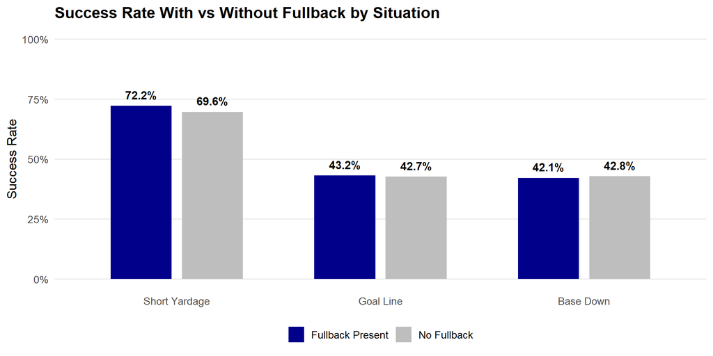

## Effect of Fullback Presence — Base Models

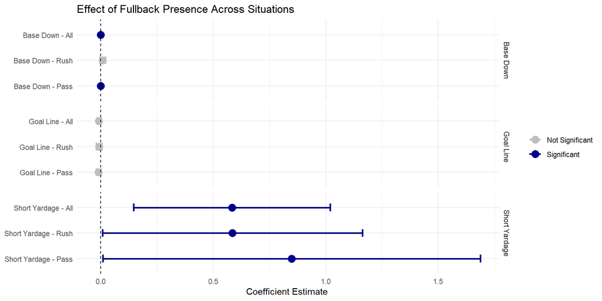

## Effect of Fullback Presence — Random Effects Models

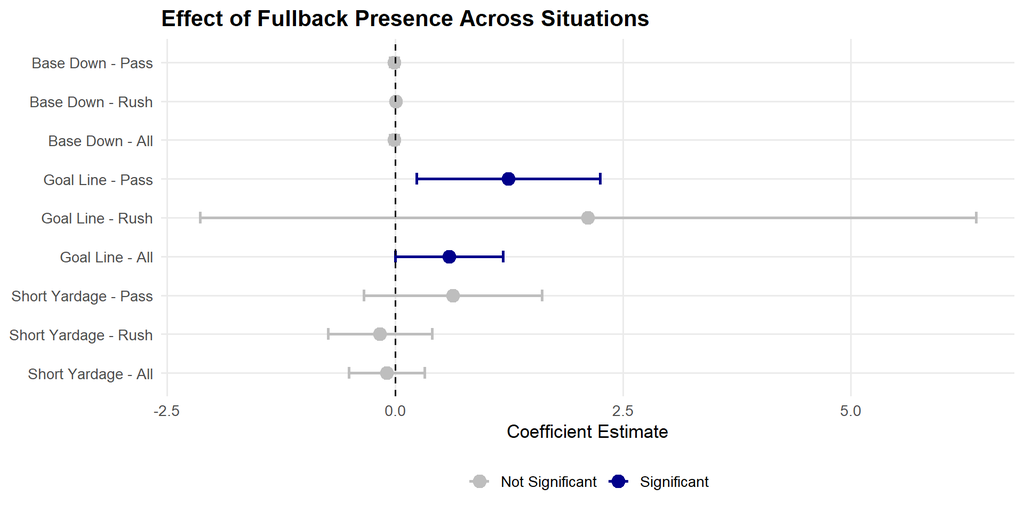

## Individual Fullback Differences

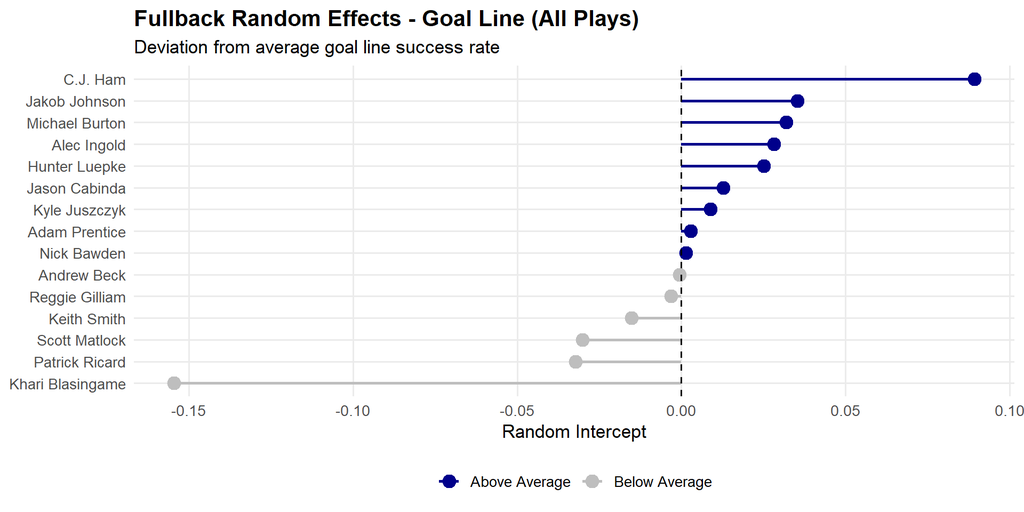

# Conclusion

## Key Takeaways

- Fullbacks provide **measurable value** in short yardage situations
- It is valuable to have a fullback on roster
- Individual fullback identity matters most at the **goal line**
- Base down value is limited

## Limitations

- Position-level data only available for 2023-2024
- Only 15 identified fullbacks; limits random effects precision
- Cannot capture blocking value or play-action threat contributions

## Future Work

- Expand to more seasons as position data becomes available
- Incorporate tracking data to measure blocking contributions
- Compare fullback value against tight end in same formations

# Thank You

**Micah Barnett — Rice University — SMGT 490**